# De l’approche bayésienne au modèle de série temporelle

Modèle BSTS appliqué au cours de l’or

R

BSTS

gold

Auteur·rice

GOLLENTZ Quentin

Date de publication

01-04-2026

# Modèle BSTS pour la prédiction du cours de l’or

## Introduction

Le modèle **BSTS** (Bayesian Structural Time Series) est une approche puissante pour la modélisation et la prédiction de séries temporelles, combinant des composantes structurelles (tendance, saisonnalité, régresseurs) avec une inférence bayésienne. Ce document détaille son application à la prédiction du cours de l’or, en explicitant la formulation mathématique, l’inférence bayésienne et le choix des distributions a priori.

## 1. Formulation mathématique du modèle BSTS

Le modèle BSTS décompose la série temporelle$y_t$(ici, le cours de l’or) en plusieurs composantes additives :

$$y_{t} = \underbrace{\mu_{t}}_{trend} + \underbrace{\gamma_{t}}_{seasonal} + \underbrace{\beta^{T}x_{t}}_{regression} + \epsilon_{t}$$

- $y_{t}$: cours de l’or au temps $t$.
- $\mu_{t}$: tendance (ex : hausse constante).
- $\gamma_{t}$: saisonnalité (ex : effet du Nouvel An chinois).
- $\beta^{T}x_{t}$: effets des variables explicatives (ex : taux directeur de la FED).
- $\epsilon_{t}$: bruit blanc gaussien,$\epsilon_t \sim \mathcal{N}(0, \sigma^2_\epsilon)$.

### 1.1. Modélisation de la tendance locale linéaire

La tendance est modélisée par un **modèle local linéaire** :

$$\begin{aligned}
\mu_{t} &= \mu_{t-1} + \delta_{t-1} + u_{t}, \quad u_t \sim \mathcal{N}(0, \sigma^2_u) \\
\delta_{t} &= \delta_{t-1} + v_{t}, \quad v_t \sim \mathcal{N}(0, \sigma^2_v)
\end{aligned}$$

- $\mu_t$: niveau de la série au temps $t$.
- $\delta_t$: pente de la tendance.
- $u_t, v_t$: bruits gaussiens de variances$\sigma^2_u, \sigma^2_v$.

### 1.2. Modélisation de la saisonnalité stochastique

$$\gamma_{t} = -\sum_{s=1}^{S-1}\gamma_{t-s} + w_{t}, \quad w_t \sim \mathcal{N}(0, \sigma^2_w)$$

- $S$: période saisonnière (ex : 12 pour des données mensuelles).
- $w_t$: bruit saisonnier, de variance$\sigma^2_w$.

## 2. Inférence bayésienne dans BSTS

L’inférence bayésienne consiste à déduire la **distribution postérieure** des paramètres $p(\theta|X,y)$, où $\theta$ représente l’ensemble des paramètres du modèle,$X$ la matrice des régresseurs et$y$le vecteur des observations.

### 2.1. Théorème de Bayes

$$\underbrace{p(\theta|X,y)}_{postérieur} \propto \underbrace{p(y|X,\theta)}_{vraissemblance} \times \underbrace{p(\theta)}_{prior}$$

- **Vraissemblance** :$p(y|X,\theta)$mesure la compatibilité des données avec les paramètres.
- **Prior** :$p(\theta)$encode les connaissances a priori sur les paramètres.

### 2.2 Exemple illustratif en R

```r
library(statsr)
library(ggplot2)
library(tidyverse)

data(tapwater)
glimpse(tapwater)
```

```
Rows: 28
Columns: 6
$ date       <fct> 2009-02-25, 2008-12-22, 2008-09-25, 2008-05-14, 2008-04-14,…
$ tthm       <dbl> 34.38, 39.33, 108.63, 88.00, 81.00, 49.25, 75.00, 82.86, 85…
$ samples    <int> 8, 9, 8, 8, 2, 8, 6, 7, 8, 4, 4, 4, 4, 6, 4, 8, 10, 10, 10,…
$ nondetects <int> 0, 0, 0, 0, 0, 0, 0, 0, 0, 0, 0, 0, 0, 0, 0, 0, 0, 0, 0, 0,…
$ min        <dbl> 32.00, 31.00, 85.00, 75.00, 81.00, 26.00, 70.00, 70.00, 80.…
$ max        <dbl> 39.00, 46.00, 120.00, 94.00, 81.00, 68.00, 80.00, 90.00, 90…
```

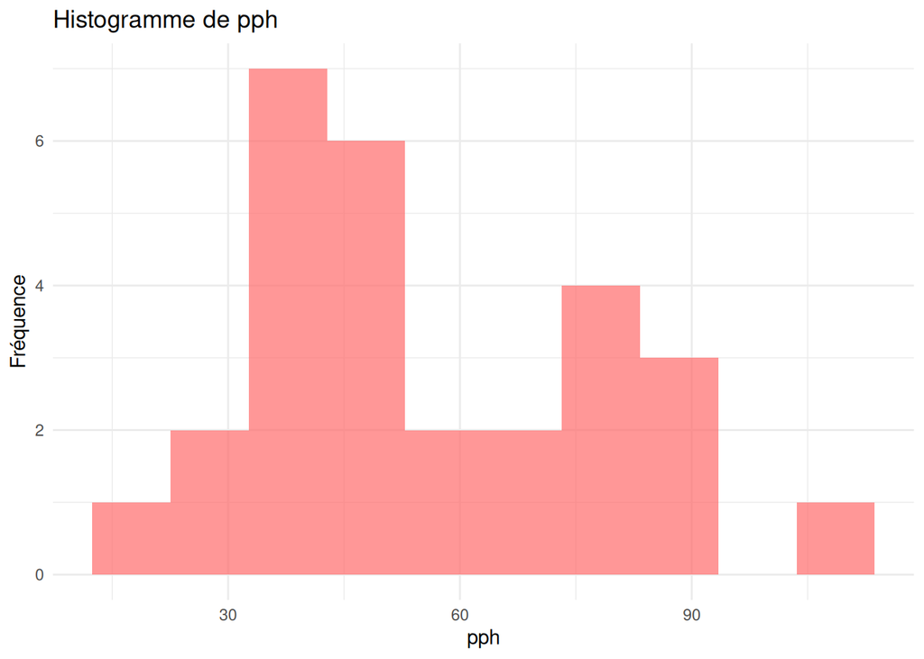

```r
ggplot(tapwater, aes(x = tthm)) +
  geom_histogram(bins = 10, fill = "#FF6B6B", alpha = 0.7) +
  labs(
    title = "Histogramme de pph",
    x = "pph",
    y = "Fréquence"
  ) +
  theme_minimal()
```

```r
set.seed(42)

# Hyperparamètres du prior
m_0 = 35
n_0 = 25
s2_0 = 156.25
v_0 = n_0 - 1

# Statistiques de l'échantillon
Y = tapwater$tthm
ybar = mean(Y)
s2 = var(Y)
n = length(Y)

# Hyperparamètres du posterior
n_n = n_0 + n
m_n = (n*ybar + n_0*m_0) / n_n
v_n = v_0 + n
s2_n = ((n-1)*s2 + v_0*s2_0 + n_0*n*(m_0 - ybar)^2/n_n) / v_n

# Inference statsr
bayes_inference(
  tthm, data = tapwater, prior = "NG",
  mu_0 = m_0, n_0 = n_0, s_0 = sqrt(s2_0), v_0 = v_0,
  stat = "mean", type = "ci", method = "theoretical",
  show_res = TRUE, show_summ = TRUE, show_plot = FALSE
)
```

```
Single numerical variable
n = 28, y-bar = 55.5239, s = 23.254
(Assuming proper prior:  mu | sigma^2 ~ N(35, *sigma^2/25)
(Assuming proper prior: 1/sigma^2 ~ G(24/2,156.25*24/2)

Joint Posterior Distribution for mu and 1/sigma^2:
 N(45.8428, sigma^2/53) G(52/2, 8.6769*52/2)

Marginal Posterior for mu:
Student t with posterior mean = 45.8428, posterior scale = 2.9457 on 52 df

95% CI: (39.9319 , 51.7537)
```

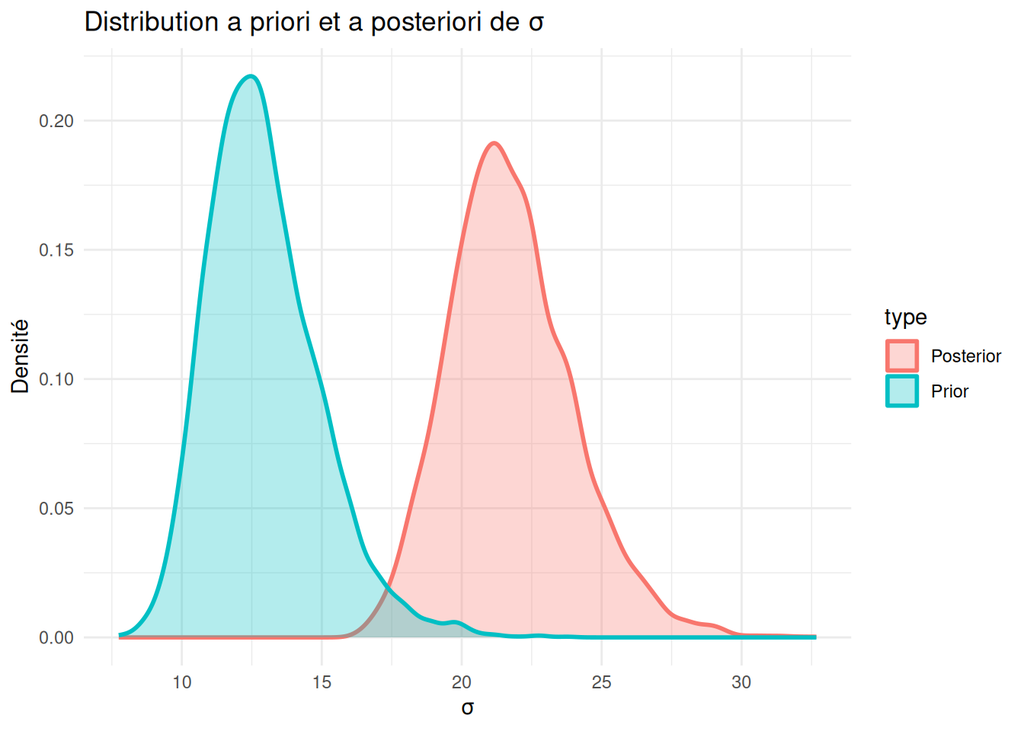

```r
# -----------------------------
# 1. Distribution de sigma (prior & posterior)
# -----------------------------

# Prior : phi = 1/sigma^2 ~ Gamma(v0/2, v0*s2_0/2)
phi_prior = rgamma(5000, shape = v_0/2, rate = v_0*s2_0/2)
sigma_prior = 1/sqrt(phi_prior)

# Posterior : phi_n = 1/sigma^2 ~ Gamma(vn/2, vn*s2_n/2)
phi_post = rgamma(5000, shape = v_n/2, rate = v_n*s2_n/2)
sigma_post = 1/sqrt(phi_post)

df_sigma = tibble(
  sigma = c(sigma_prior, sigma_post),
  type = rep(c("Prior", "Posterior"), each = 5000)
)

ggplot(df_sigma, aes(x = sigma, fill = type, color = type)) +
  geom_density(alpha = 0.3, linewidth = 1) +
  labs(
    title = "Distribution a priori et a posteriori de σ",
    x = "σ",
    y = "Densité"
  ) +
  theme_minimal()
```

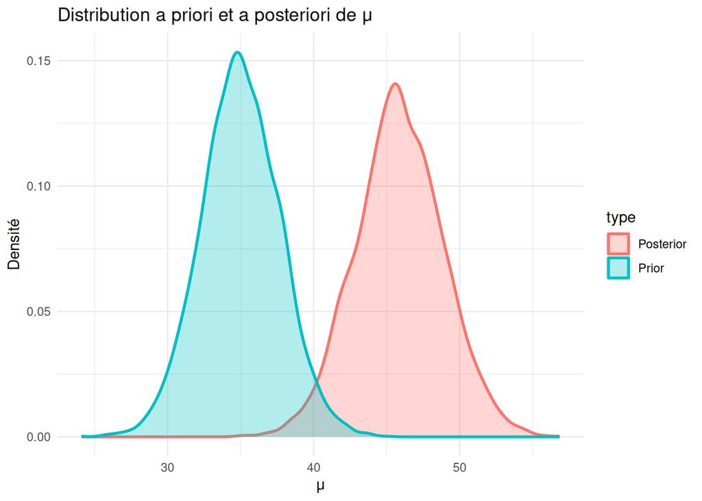

```r
# -----------------------------
# 2. Distribution de mu (prior & posterior)
# -----------------------------

# Prior : mu ~ Normal(m0, sigma/sqrt(n0))
mu_prior = rnorm(5000, mean = m_0, sd = sigma_prior / sqrt(n_0))

# Posterior : mu_n ~ Normal(mn, sigma/sqrt(nn))
mu_post = rnorm(5000, mean = m_n, sd = sigma_post / sqrt(n_n))

df_mu = tibble(
  mu = c(mu_prior, mu_post),
  type = rep(c("Prior", "Posterior"), each = 5000)
)

ggplot(df_mu, aes(x = mu, fill = type, color = type)) +
  geom_density(alpha = 0.3, linewidth = 1) +
  labs(
    title = "Distribution a priori et a posteriori de μ",
    x = "μ",
    y = "Densité"
  ) +
  theme_minimal()
```

### 2.2. Choix des distributions a priori

Chaque composante du modèle BSTS a ses propres paramètres, auxquels on assigne des **priors Inverse-Gamma** pour les variances et des **priors Normaux** pour les coefficients.

#### a. Tendance

| Paramètre | Prior typique | Rôle |
| --- | --- | --- |
| $\sigma^2_u$ | Inv-Gamma(0.01, 0.01) | Variabilité du niveau de la tendance. |
| $\sigma^2_v$ | Inv-Gamma(0.01, 0.01) | Variabilité de la pente de la tendance. |

#### b. Saisonnalité

| Paramètre | Prior typique | Rôle |
| --- | --- | --- |
| $\sigma^2_w$ | Inv-Gamma(0.1, 0.1) | Variabilité des amplitudes saisonnières. |

#### c. Régresseurs

| Paramètre | Prior typique | Rôle |
| --- | --- | --- |
| $\beta_j$ | Normal(0,$\sigma^2_\beta$) | Coefficients de régression. |
| $\sigma^2_\beta$ | Inv-Gamma(0.01, 0.01) | Variabilité des coefficients. |

#### d. Bruit global

| Paramètre | Prior typique | Rôle |
| --- | --- | --- |
| $\sigma^2_\epsilon$ | Inv-Gamma(0.001, 0.001) | Variabilité résiduelle non expliquée. |

## 3. Implémentation pratique avec `bsts` en R

Voici un exemple minimal d’implémentation du modèle BSTS pour prédire le cours de l’or :

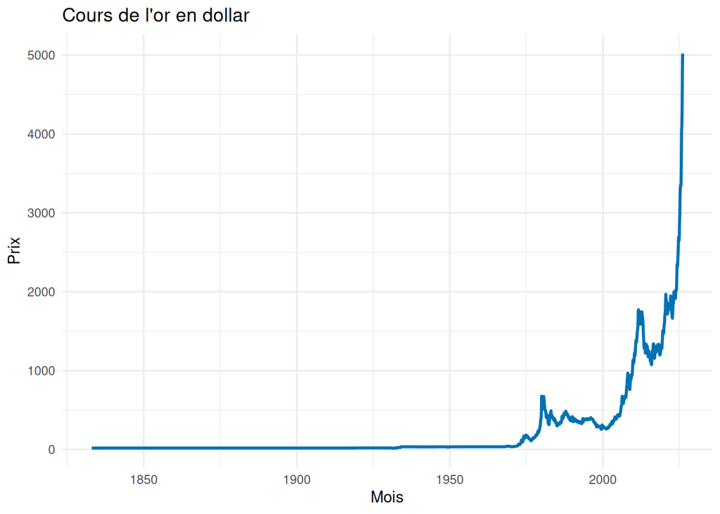

```r
library(bsts)
library(readr)
library(dplyr)
library(lubridate)
library(tidyverse)

path <- getwd()
gold <- read.csv(paste0(path,"/data/monthly.csv"))

gold <- gold %>%
  mutate(
    Date = paste0(Date, "-01"),  # transforme 2025-04 → 2025-04-01
    Date = as.Date(Date)
  ) %>%
  arrange(Date)

ggplot(gold, aes(x = Date, y = Price)) +
  geom_line(color = "#0072B2", linewidth = 1) +
  labs(
    title = "Cours de l'or en dollar",
    x = "Mois",
    y = "Prix"
  ) +
  theme_minimal()
```

```r
#Modelisation
y <- gold$Price %>% as.double()
# Mise en log
y <- log(y)

ss <- AddLocalLinearTrend(list(), y)
ss <- AddSeasonal(ss, y, nseasons = 12)
model1 <- bsts(y,state.specification = ss,niter = 1000)
```

```
=-=-=-=-= Iteration 0 Fri Apr  3 14:12:22 2026 =-=-=-=-=
=-=-=-=-= Iteration 100 Fri Apr  3 14:12:25 2026 =-=-=-=-=
=-=-=-=-= Iteration 200 Fri Apr  3 14:12:27 2026 =-=-=-=-=
=-=-=-=-= Iteration 300 Fri Apr  3 14:12:29 2026 =-=-=-=-=
=-=-=-=-= Iteration 400 Fri Apr  3 14:12:31 2026 =-=-=-=-=
=-=-=-=-= Iteration 500 Fri Apr  3 14:12:33 2026 =-=-=-=-=
=-=-=-=-= Iteration 600 Fri Apr  3 14:12:35 2026 =-=-=-=-=
=-=-=-=-= Iteration 700 Fri Apr  3 14:12:37 2026 =-=-=-=-=
=-=-=-=-= Iteration 800 Fri Apr  3 14:12:40 2026 =-=-=-=-=
=-=-=-=-= Iteration 900 Fri Apr  3 14:12:42 2026 =-=-=-=-=
```

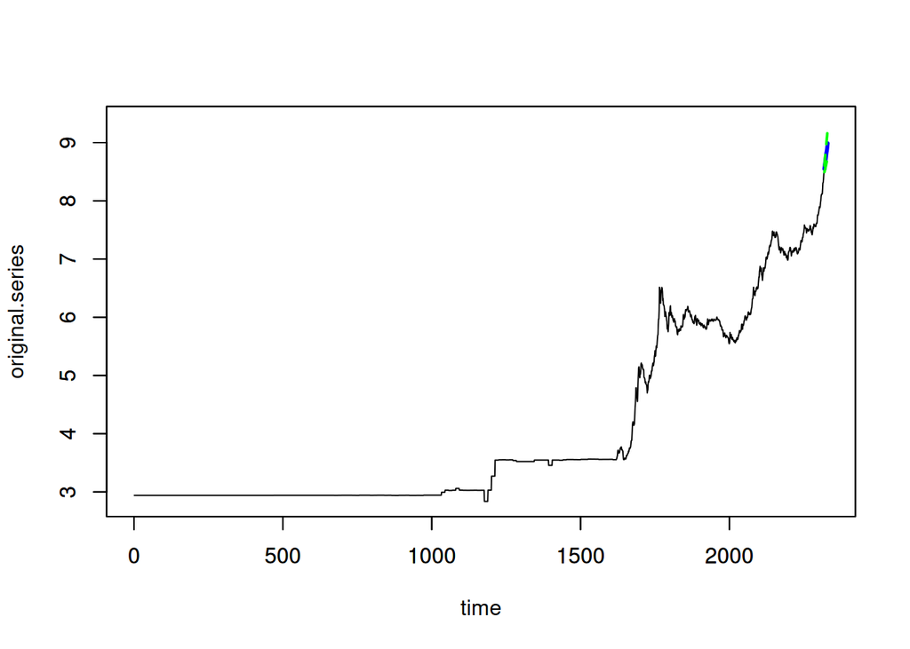

```r
pred_r <- predict(model1, horizon = 12)
plot(pred_r)
```